# Week3_Revamp

## Week 3 : SIR Process

Imagine a disease. Nodes are in 3 states, S/I/R When a node is I, they will remain I for 1 week and then be R. When a node is I, they will cause their adjacent nodes to be I with probability $\lambda$, independently. A person who is R will no longer partake in any dynamic process.

To start the outbreak, define an initial condition. Almost all the nodes are S, a small fraction of nodes chosen uniformly at random, begin as I.

Terminal state is when we only have nodes of S/R and no I left.

Assumptions:

[Differential Relationships] : https://maa.org/press/periodicals/loci/joma/the-sir-model-for-spread-of-disease-the-differential-equation-model

[Implementing in Python] : https://pythonhosted.org/epydemic/sir.html#:~:text=The%20Susceptible%2DInfected%2DRemoved%20compartmented,Kermack%20and%20McKendrick%20in%201927.

[Network Analysis to Identify the Risk of Epidemic Spreading] : https://www.mdpi.com/2076-3417/11/7/2997#:~:text=where%20S%2C%20I%2C%20and%20R,the%20whole%20population%20size%20N.

[Two critical times for the SIR model] : https://bpb-us-w2.wpmucdn.com/web.sas.upenn.edu/dist/6/47/files/2021/07/1-s2.0-S0022247X21005862-main.pdf

[Exploring the threshold of epidemic spreading for a stochastic SIR model with local and global contacts] : https://www.sciencedirect.com/science/article/pii/S0378437119318035#:~:text=The%20threshold%20for%20epidemic%20spreading%20that%20in%20both%20versions%20of,1%20is%20of%20particular%20interest.

# Q1

Generating model with nodes $n$ and mean $k$ :

Motivation for the Configuration Model over the Random Model

The configuration model is a model in which the degrees of vertices are fixed beforehand. Such a model is more flexible than the generalized random graph. For example, the generalized random graph always has a positive proportion of vertices of degree 0, 1, 2, etc. . In some real-world networks, however, it is natural to investigate graphs where every vertex has at least one or two neighbors.

For various $\lambda$ values, run until only S/R state are left.

```python
import numpy as np
import scipy.stats as scistats
import matplotlib.pyplot as plt
import random
from collections import Counter
from scipy.cluster.hierarchy import DisjointSet
```

```python
class Network():
    def __init__(self,num_nodes):
        self.adj = {i:set() for i in range(num_nodes)}
        self.num_edge = 0
        self.num_nodes = num_nodes

    def add_edge(self,i,j):
        self.adj[i].add(j)
        self.adj[j].add(i)
        self.num_edge+=1

    def neighbors (self,i):
        return self.adj[i]

    def edge_list(self):
        return [(i,j) for i in self.adj for j in self.adj[i] if i<j]
```

```python
class Erdos_renyi_Network(Network):

    def __init__(self, num_nodes, mean):
        super().__init__(num_nodes)

        # Parameter p for a Erdos-renyi Graph
        self.p = mean/(num_nodes-1)

        # Construct Erdos-renyi Graph
        for i in range(num_nodes):
            for j in range(i+1,num_nodes):
                if np.random.random()<self.p:
                    self.add_edge(i,j)
```

```python
class SIR_Model():

    def __init__(self, network: Erdos_renyi_Network, p_infected,p_infect):

        self.p_infected = p_infected
        self.p_infect = p_infect
        self.network = network

        # SIR nodes
        self.S = {node for node in range(self.network.num_nodes)}
        self.I = set()
        self.R = set()

        # Initially infect a small fraction of the population
        self.I.update(np.random.choice(list(self.S), size=int(self.p_infected*self.network.num_nodes), replace=False))
        self.S.difference_update(self.I)

    def run(self):
        '''Runs simulation for a cycle'''

        new_I = set()
        for node in self.I:
            for adj in self.network.neighbors(node):
                if adj in self.S and np.random.random()<self.p_infect:
                    new_I.add(adj)

            self.R.add(node)

        self.I.difference_update(self.R)
        self.I.update(new_I)
        self.S.difference_update(self.I)


    def run_to_extinction(self):
        '''Runs simulation until extinction, then returns time series of SIR numbers as arrays'''

        S_list, I_list, R_list = [len(self.S)], [len(self.I)], [len(self.R)]

        while self.I:

            self.run()

            S_list.append(len(self.S))
            I_list.append(len(self.I))
            R_list.append(len(self.R))

        return S_list, I_list, R_list
```

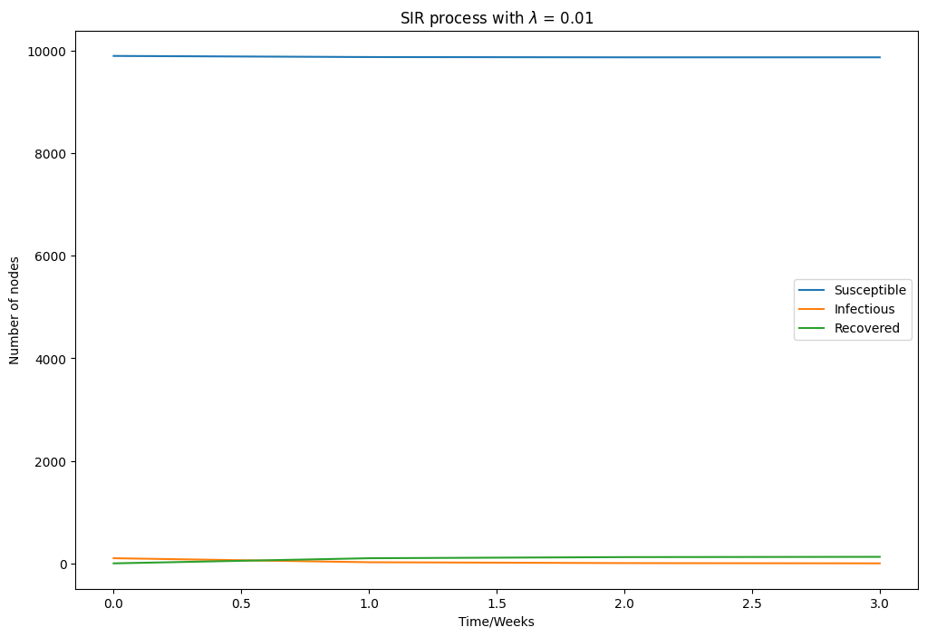

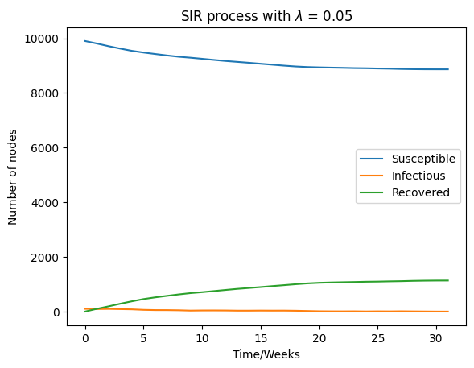

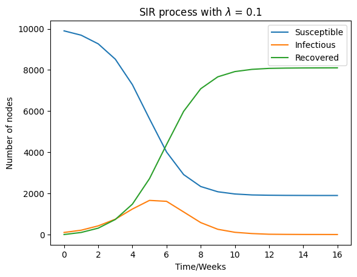

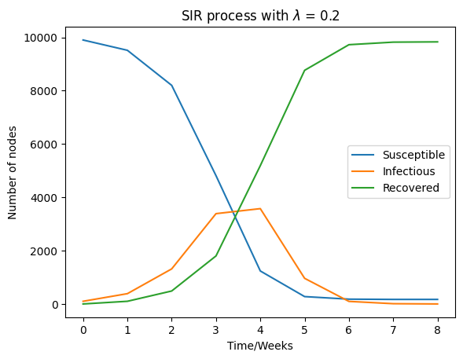

```python
n = 10000
k = 20
p_infected=0.01
p_infect_array = [0.01,0.05,0.1,0.2]
network = Erdos_renyi_Network(n,k)

plt.figure(figsize=(12,8))
for p_infect in p_infect_array:
    simulation = SIR_Model(network,p_infected, p_infect)
    S,I,R = simulation.run_to_extinction()

    plt.plot(S, label='Susceptible')
    plt.plot(I, label='Infectious')
    plt.plot(R, label='Recovered')
    plt.xlabel('Time/Weeks')
    plt.ylabel('Number of nodes')
    plt.title(r'SIR process with $\lambda$ = {}'.format(p_infect))
    plt.legend()
    plt.show()
```

# Q2

For a range of $\lambda$ values, inevstigate the number of nodes in state R at the point of extinction. Average over many simulations.

Investigate $\lambda*$, the threshold value when the outbreak goes from only infecting a small fraction to large fraction.

In SIR models, lambda (λ) determines how infectious a disease is. There is a critical value, λc, that separates two qualitatively different dynamical regimes. Here's a basic understanding of those regimes:

Below λc: An outbreak cannot be sustained in the long term. The disease may die out after infecting a small fraction of the population. Above λc: An outbreak can occur and a larger portion of the population will be infected.

```python
def average_R_vs_lambda(network, p_infect_array, p_infected=0.01, runs=100):
    avg_R = []

    for p_infect in p_infect_array:
        R_values = []
        for _ in range(runs):
            simulation = SIR_Model(network,p_infected, p_infect)
            S,I,R = simulation.run_to_extinction()
            R_values.append(R[-1])
        avg_R.append(np.mean(R_values))

    return avg_R

p_infect_array = np.linspace(0.01,0.2,30)
avg_R = average_R_vs_lambda(network, p_infect_array)
```

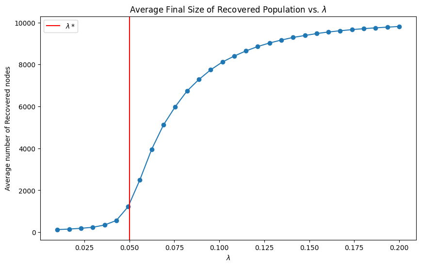

```python
plt.figure(figsize=(10,6))
plt.plot(p_infect_array,avg_R, marker='o')
plt.axvline(0.05,label=r'$\lambda*$', color='r')
plt.legend()
plt.xlabel(r'$\lambda$')
plt.ylabel('Average number of Recovered nodes')
plt.title(r'Average Final Size of Recovered Population vs. $\lambda$')
plt.show()
```

# Q3

Let $s_{i}$ be the probability that node $i$ is never infected.

https://www.ncbi.nlm.nih.gov/pmc/articles/PMC3478503/

$$s_{i} = \prod_{j} (1-\lambda + s_{j}\lambda)^{A_{ij}}$$

Noting that $j$ are the neighbours of i.

Solve by iteration

1. Fix $s_{i}\in [0,1]$ to random values.
2. Iterate the equation until it converges.

Compare the predictions of this equation to simulations.

By taking the log of the above equation, relate the stability of $\textbf{s}=1$ fixed point to the eigenvalues of A, the adjacent matrix.

Relate this to the simulation and epidemic threshold.

```python
def approx_R_prob_vs_lambda(network, p_infect_array, tol=1e-6, max_iter=20):
    """Returns approximate average probability of final recovered size by iterative method"""
    approx_R = []

    for p_infect in p_infect_array:
        s = np.random.uniform(size=n)

        for _ in range(max_iter):
            s_new = np.ones(network.num_nodes)
            for i in range(n):
                s_new[i]  = np.prod([1+p_infect*(-1+s[j]) for j in network.adj[i]])
            if np.linalg.norm(s_new-s)<tol:
                break
            s = s_new

        approx_R.append(1-np.mean(s))

    return approx_R

approx_R_prob = approx_R_prob_vs_lambda(network,p_infect_array)
```

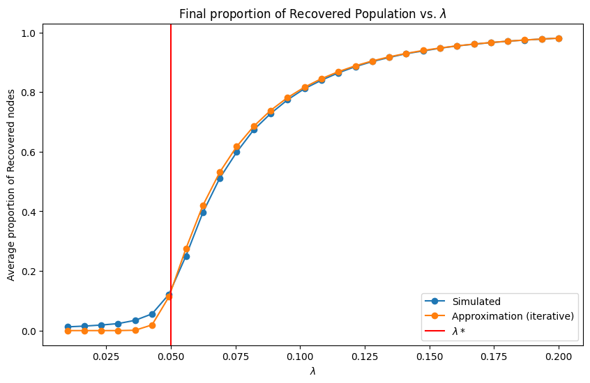

```python
plt.figure(figsize=(10,6))
plt.plot(p_infect_array,np.array(avg_R)/network.num_nodes, marker='o',label='Simulated')
plt.plot(p_infect_array,approx_R_prob, marker='o',label='Approximation (iterative)')
plt.axvline(0.05,label=r'$\lambda*$', color='r')
plt.legend()
plt.xlabel(r'$\lambda$')
plt.ylabel('Average proportion of Recovered nodes')
plt.title(r'Final proportion of Recovered Population vs. $\lambda$')
plt.show()
```

The iterative equation and simulation match quite well.

# Q4

Simulating the whole process can be done more efficiently using Disjoint Set structure.

1. First construct configuration graph as usual.
2. For each edge i,j, merge them with probability $\lambda$.
3. Then estimate mean and std deviation of cluster size for the approximate range $\lambda \in (0,3\lambda_{c})$. Where $\lambda_{c}$ is the epidemic threshold.

```python
def disjoint_simulation(network, p_infect):
    '''Simulates infection using disjoint set method. Then returns the mean and std cluster_sizes in the network '''

    C = DisjointSet(range(network.num_nodes))
    for i,j in network.edge_list():
        if np.random.random() < p_infect:
            C.merge(i,j)

    cluster_sizes = [len(C.subset(node)) for node in C]

    return np.mean(cluster_sizes),np.std(cluster_sizes)

mean_cluster_sizes = []
std_cluster_sizes = []

P_infect_array = np.linspace(0,0.05*3,20)

for p_infect in p_infect_array:
    cluster_mean,cluster_std = disjoint_simulation(network,p_infect)
    mean_cluster_sizes.append(cluster_mean)
    std_cluster_sizes.append(cluster_std)
```

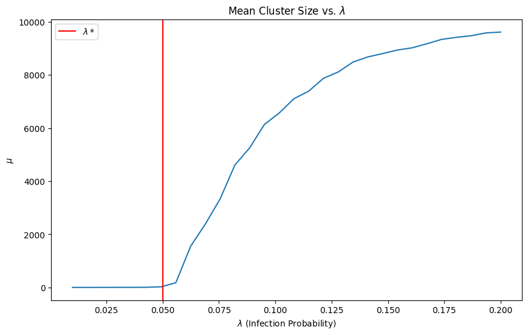

```python
# Plotting the results
plt.figure(figsize=(10, 6))
plt.plot(p_infect_array, mean_cluster_sizes)
plt.axvline(0.05,color='r',label=r'$\lambda*$')
plt.xlabel(r'$\lambda$ (Infection Probability)')
plt.ylabel(r'$\mu$')
plt.title(r'Mean Cluster Size vs. $\lambda$')
plt.legend()
plt.show()
```

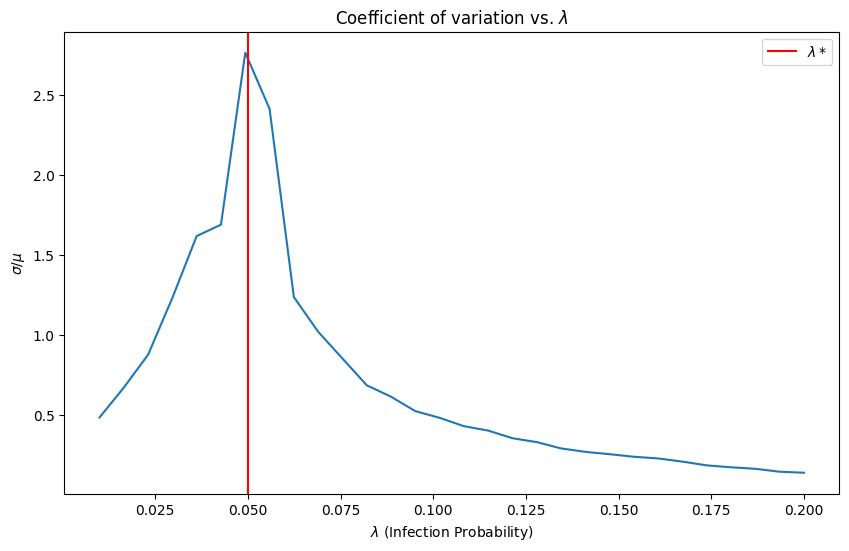

```python
# Plotting the results
plt.figure(figsize=(10, 6))
plt.plot(p_infect_array, np.array(std_cluster_sizes)/np.array(mean_cluster_sizes))
plt.axvline(0.05,color='r',label=r'$\lambda*$')
plt.xlabel(r'$\lambda$ (Infection Probability)')
plt.ylabel(r'$\sigma / \mu$')
plt.title(r'Coefficient of variation vs. $\lambda$')
plt.legend()
plt.show()
```

The coefficient of variation (σ/μ) is a measure of variability relative to the mean. In the context of the SIR model, it might represent the variability in the size of clusters of infected individuals.

# Q5 Even more efficient simulation

This is an efficent way of determining cluster sizes as a function of $\lambda$ via one sweep through all edges.

1. Generate a configuration network as usual
2. Let $k$ be the current number of edges selected/worked through.
3. Compute average cluster size at each $k \in [1,m]$.
4. Then compute average cluster size for a given $\lambda$ using binomial distribution with argument k and total size m.

```python
def efficient_disjoint_simulation(network):
    '''Efficiently simulates infection using disjoint set method. Then returns average cluster size at each k for the network '''

    cluster_sizes_vs_k = []
    edges = network.edge_list()

    random.shuffle(edges)
    C = DisjointSet(range(network.num_nodes))

    for k in range(network.num_edge):
        i,j = edges[k]
        C.merge(i,j)

        cluster_sizes_vs_k.append(len(C.subset(0)))

    return cluster_sizes_vs_k

cluster_sizes_vs_k = efficient_disjoint_simulation(network)
```

```python
mean_cluster_sizes_efficient = []

for p_infect in p_infect_array:
    probability_array = scistats.binom.pmf([k for k in range(1,network.num_edge+1)], network.num_edge, p_infect)
    mean_cluster_sizes_efficient.append(np.sum(np.array(cluster_sizes_vs_k)*np.array(probability_array)))
```

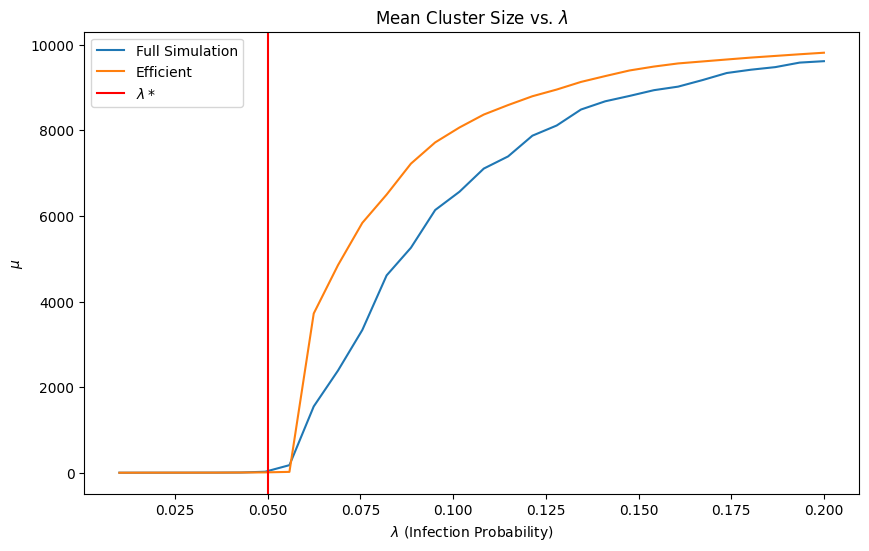

```python
# Plotting the results
plt.figure(figsize=(10, 6))
plt.plot(p_infect_array, mean_cluster_sizes,label='Full Simulation')
plt.plot(p_infect_array, mean_cluster_sizes_efficient,label='Efficient')
plt.axvline(0.05,color='r',label=r'$\lambda*$')
plt.xlabel(r'$\lambda$ (Infection Probability)')
plt.ylabel(r'$\mu$')
plt.title(r'Mean Cluster Size vs. $\lambda$')
plt.legend()
plt.show()
```